# Practical ML

Nathania

November 25, 2018

### Read the Data

After downloading the data from the data source, we can read the two csv files into two data frames.

```r
library(RCurl)
```

```r
URLtrain <-"https://d396qusza40orc.cloudfront.net/predmachlearn/pml-training.csv"
x <- getURL(URLtrain)
train <- read.csv(textConnection(x))
URLtest <-"https://d396qusza40orc.cloudfront.net/predmachlearn/pml-testing.csv"
x <- getURL(URLtest)
test <- read.csv(textConnection(x))
```

### Clean Data

In this step, we will clean the data and get rid of observations with missing values as well as some meaningless variables.

```r
sum(is.na(train))
```

```
## [1] 1287472
```

#### Handling Missing values

```r
library(tidyverse)
trainClean <- train[, colSums((is.na(train)))==0]
testClean <- test[, colSums((is.na(test))) == 0]
```

```r
classe <- trainClean$classe

trainRemove <- grepl("^X|timestamp|window", names(trainClean))
trainClean <- trainClean[, !trainRemove]
trainCleaned <- trainClean[, sapply(trainClean, is.numeric)]
trainCleaned$classe <- classe
testRemove <- grepl("^X|timestamp|window", names(testClean))
testClean <- testClean[, !testRemove]
testCleaned <- testClean[, sapply(testClean, is.numeric)]
```

Now, the cleaned training data set contains 19622 observations and 53 variables, while the testing data set contains 20 observations and 53 variables. The “classe” variable is still in the cleaned training set.

### Partitioned Training Set

Then, we can split the cleaned training set into a pure training data set (80%) and a validation data set (20%).The validation data set will used for cross validation in future steps.

```r
library(caret)
set.seed(23123)
inTrain <- createDataPartition(trainCleaned$classe, p=0.80, list=F)
trainSet <- trainCleaned[inTrain, ]
validSet <- trainCleaned[-inTrain, ]
```

```r
# function for determining sparseness of variables
sparse <- function(b) {
    n <- length(b)
    na.count <- sum(is.na(b))
    return((n - na.count)/n)
}

# sparness of input variables based on training subset
varSparse <- apply(trainSet, 2, sparse)

# trim down the subs by removing sparse variables
trimTrainSub <- trainSet[, varSparse > 0.9]
```

### Data Modeling

We fit a predictive model for activity recognition using **Random Forest** algorithm because it automatically selects important variables and is robust to correlated covariates & outliers in general. We will use **5 and 10 -fold cross validation** for comparison.

#### Determine Predictor by measuring Variable Importance

Here, 20% from the training data will used to determine variable importance

```r
inVarImp <- createDataPartition(y = trimTrainSub$classe, p = 0.2, list = F)
varImpSub <- trimTrainSub[inVarImp,]
RF <-  train(classe ~ ., data = varImpSub, method = "rf")
```

Let’s observe the importance variable

[figure not shown]

```r
library(tidyverse)
varImpObj <- varImp(RF)
df <- as.data.frame(cbind(rownames(varImpObj$importance), varImpObj$importance$Overall))
colnames(df) <- c("Feature", "Importance")
df <- df %>% arrange(desc(Importance))
ggplot(df, aes(Importance, Feature))+
  geom_bar(aes(fill=Feature), stat = "identity", show.legend=FALSE)+
  theme_bw()+ggtitle("Variable Importance of Top 52")
```

```r
top25 <- df %>% arrange(desc(Importance)) %>% top_n(25) %>% ggplot(aes(Importance, Feature))+
  geom_bar(aes(fill=Feature), stat = "identity",
           show.legend=FALSE)+
  theme_bw()+
  ggtitle("Variable Importance of Top 25")
```

Here the 60% training data (80%-20%) will used as final training set. While the feature selection will only pick top 25% variable importance

```r
set.seed(1343242)
finalTrainSet <- trimTrainSub[-inVarImp, ]
thresh <- quantile(varImpObj$importance[, 1], 0.75)
filterVar <- varImpObj$importance[, 1] >= thresh
finalTrainSet <- finalTrainSet[, filterVar]
```

```r
crf5 <- trainControl(method="cv", 5)
crf10 <- trainControl(method="cv", 10)
modRf5 <- train(classe ~ ., data=finalTrainSet, method="rf", trControl=crf5, ntree=500)
modRf10 <- train(classe ~ ., data=finalTrainSet, method="rf", trControl=crf10, ntree=500)
print("Random Forest with 5-Cross Validation")
```

```
## [1] "Random Forest with 5-Cross Validation"
```

```r
modRf5
```

```
## Random Forest
##
## 12557 samples
##    13 predictor
##     5 classes: 'A', 'B', 'C', 'D', 'E'
##
## No pre-processing
## Resampling: Cross-Validated (5 fold)
## Summary of sample sizes: 10046, 10045, 10045, 10047, 10045
## Resampling results across tuning parameters:
##
##   mtry  Accuracy   Kappa
##    2    0.9807282  0.9756217
##    7    0.9810468  0.9760265
##   13    0.9737996  0.9668611
##
## Accuracy was used to select the optimal model using the largest value.
## The final value used for the model was mtry = 7.
```

```r
print("Random Forest with 10-Cross Validation")
```

```
## [1] "Random Forest with 10-Cross Validation"
```

```r
modRf10
```

```
## Random Forest
##
## 12557 samples
##    13 predictor
##     5 classes: 'A', 'B', 'C', 'D', 'E'
##
## No pre-processing
## Resampling: Cross-Validated (10 fold)
## Summary of sample sizes: 11301, 11302, 11302, 11301, 11302, 11300, ...
## Resampling results across tuning parameters:
##
##   mtry  Accuracy   Kappa
##    2    0.9827194  0.9781414
##    7    0.9838338  0.9795506
##   13    0.9773841  0.9713949
##
## Accuracy was used to select the optimal model using the largest value.
## The final value used for the model was mtry = 7.
```

```r
validSet <- validSet[, varSparse > 0.9]
validSet <- validSet[,filterVar]

pr5 <- predict(modRf5,validSet)
print("In-Sample Error with 5-Cross Validation")
```

```
## [1] "In-Sample Error with 5-Cross Validation"
```

```r
confusionMatrix(validSet$classe,pr5)
```

```
## Confusion Matrix and Statistics
##
##           Reference
## Prediction    A    B    C    D    E
##          A 1114    1    0    0    1
##          B    0  746    9    4    0
##          C    0    6  675    3    0
##          D    0    0    5  638    0
##          E    0    1    2    7  711
##
## Overall Statistics
##
##                Accuracy : 0.9901
##                  95% CI : (0.9864, 0.9929)
##     No Information Rate : 0.284
##     P-Value [Acc > NIR] : < 2.2e-16
##
##                   Kappa : 0.9874
##  Mcnemar's Test P-Value : NA
##
## Statistics by Class:
##
##                      Class: A Class: B Class: C Class: D Class: E
## Sensitivity            1.0000   0.9894   0.9768   0.9785   0.9986
## Specificity            0.9993   0.9959   0.9972   0.9985   0.9969
## Pos Pred Value         0.9982   0.9829   0.9868   0.9922   0.9861
## Neg Pred Value         1.0000   0.9975   0.9951   0.9957   0.9997
## Prevalence             0.2840   0.1922   0.1761   0.1662   0.1815
## Detection Rate         0.2840   0.1902   0.1721   0.1626   0.1812
## Detection Prevalence   0.2845   0.1935   0.1744   0.1639   0.1838
## Balanced Accuracy      0.9996   0.9926   0.9870   0.9885   0.9977
```

```r
pr10 <- predict(modRf10,validSet)
print("In-Sample Error with 10-Cross Validation")
```

```
## [1] "In-Sample Error with 10-Cross Validation"
```

```r
confusionMatrix(validSet$classe,pr10)
```

```
## Confusion Matrix and Statistics
##
##           Reference
## Prediction    A    B    C    D    E
##          A 1112    3    0    0    1
##          B    0  745    9    4    1
##          C    0    6  675    3    0
##          D    0    0    6  637    0
##          E    0    1    2    7  711
##
## Overall Statistics
##
##                Accuracy : 0.989
##                  95% CI : (0.9853, 0.9921)
##     No Information Rate : 0.2835
##     P-Value [Acc > NIR] : < 2.2e-16
##
##                   Kappa : 0.9861
##  Mcnemar's Test P-Value : NA
##
## Statistics by Class:
##
##                      Class: A Class: B Class: C Class: D Class: E
## Sensitivity            1.0000   0.9868   0.9754   0.9785   0.9972
## Specificity            0.9986   0.9956   0.9972   0.9982   0.9969
## Pos Pred Value         0.9964   0.9816   0.9868   0.9907   0.9861
## Neg Pred Value         1.0000   0.9968   0.9948   0.9957   0.9994
## Prevalence             0.2835   0.1925   0.1764   0.1659   0.1817
## Detection Rate         0.2835   0.1899   0.1721   0.1624   0.1812
## Detection Prevalence   0.2845   0.1935   0.1744   0.1639   0.1838
## Balanced Accuracy      0.9993   0.9912   0.9863   0.9883   0.9970
```

```r
acc5 <- postResample(pr5, validSet$classe)
acc5
```

```
##  Accuracy     Kappa
## 0.9900586 0.9874275
```

```r
acc10 <- postResample(pr10, validSet$classe)
acc10
```

```
##  Accuracy     Kappa
## 0.9890390 0.9861388
```

```r
outSample5 <- 1 - as.numeric(confusionMatrix(validSet$classe, pr5)$overall[1])
outSample10 <- 1 - as.numeric(confusionMatrix(validSet$classe, pr10)$overall[1])
outSample5
```

```
## [1] 0.009941371
```

```r
outSample10
```

```
## [1] 0.010961
```

## Predicting for Test Data Set

Now, we apply the model to the original testing data set downloaded from the data source. We remove the `problem_id` column first.

```r
res5 <- predict(modRf10, testCleaned[, -length(names(testCleaned))])
res5
```

```
##  [1] B A B A A E D D A A B C B A E E A B B B
## Levels: A B C D E
```

## Appendix: Figures

1. Correlation

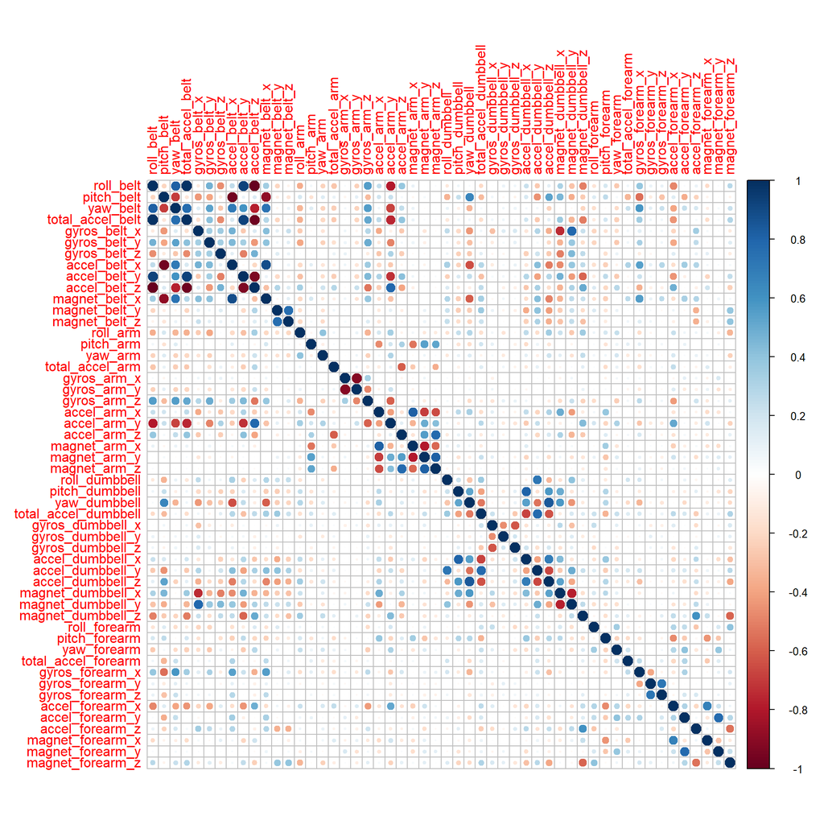

```r
library(GGally);library(corrplot)
corrdf <- cor(trainSet[, -length(names(trainSet))])
corrplot(corrdf, method="circle")
```

2. Decision Tree

```r
library(rpart);library(rattle)
```

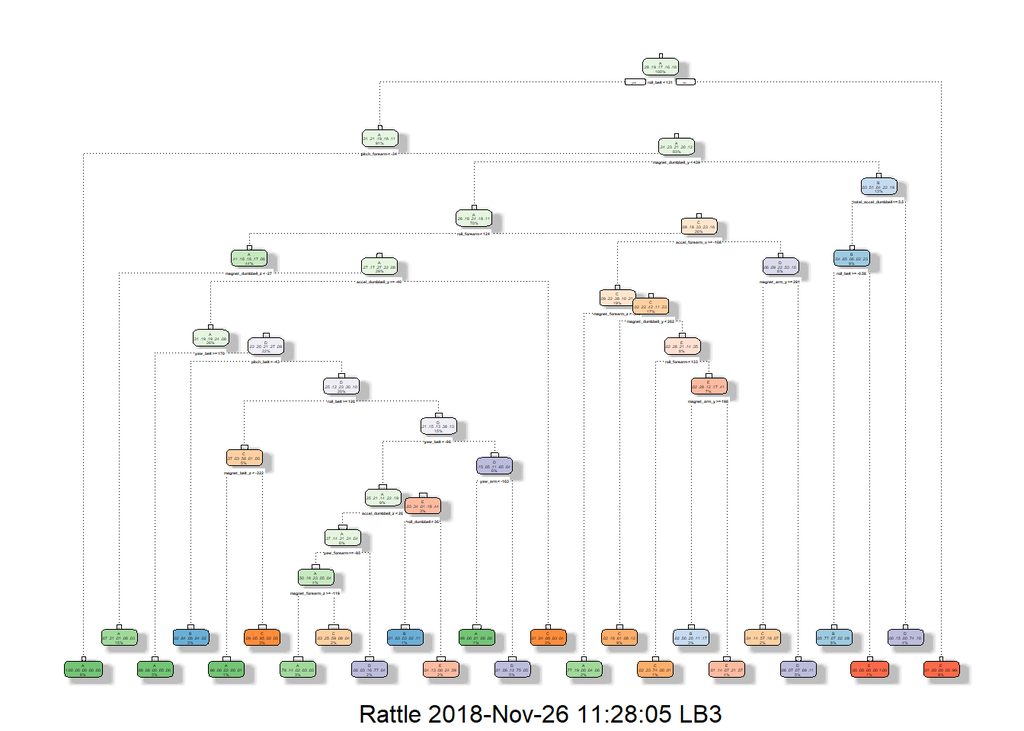

```r
mod <- rpart(classe ~ ., data=trainSet, method="class")
fancyRpartPlot(mod)
```